# Exploratory Visualization Project

## NYPD Motor Vehicle Collisions

## Outline

1. Part 1 - Exploratory Questions
2. Part 2 - Borough Analysis
3. Part 3 - Time of Day Analysis
4. Part 4 - Seasonal (Monthly) Analysis
5. Part 5 - Location (Zipcode) Analysis
6. Part 6 - Conclusions and Furter Analysis

## **Part 1**

### Exploratory Questions

## Exploratory Questions

1. How does Borough effects number of deaths?
2. How does driving time in the day effects number of deaths?
3. How does driving location (according to Zipcodes) effects number of deaths?

## Dataset

1. 769054 Observations
2. 29 variables
3. Packages Used
   1. dplyr
   2. ggplot2
   3. ggthemes
   4. chron
   5. choroplethr, choroplethrZip, devtools
   6. zipcode
4. The year data starts from the 7th month of 2012 and ends at 3rd month of 2016

## **Part 2**

### Borough Analysis

## Borough Analysis

1. Total People Deaths by Borough
2. Total Cyclist Deaths by Borough
3. Total Pedestrian Deaths by Borough
4. Total Motorist Deaths by Borough

## Total People Deaths by Borough

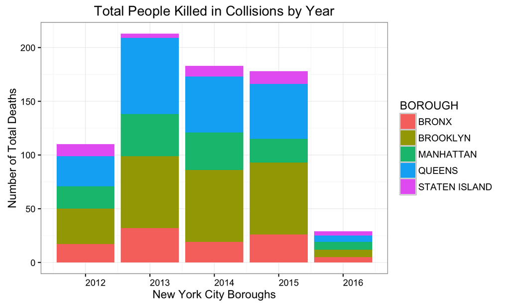

## Total Cyclist Deaths by Borough

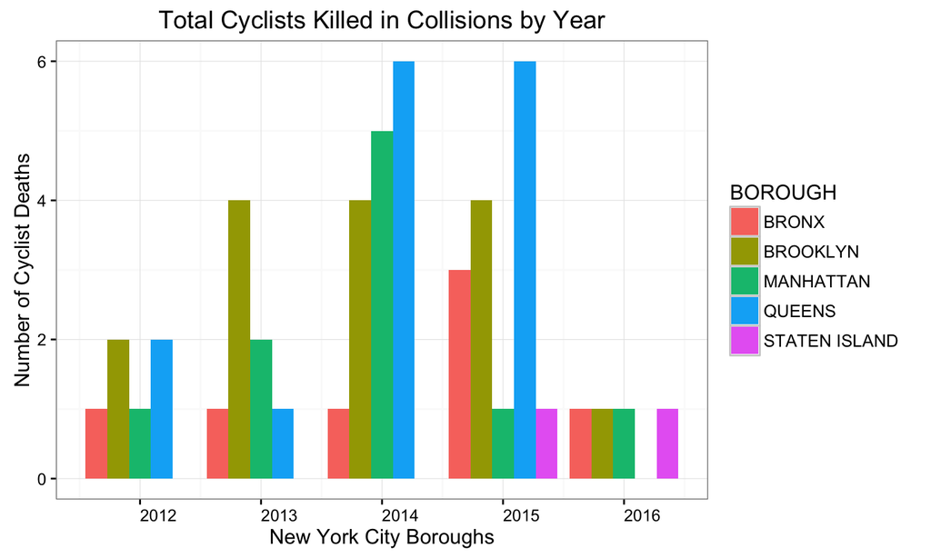

## Total Pedestrian Deaths by Borough

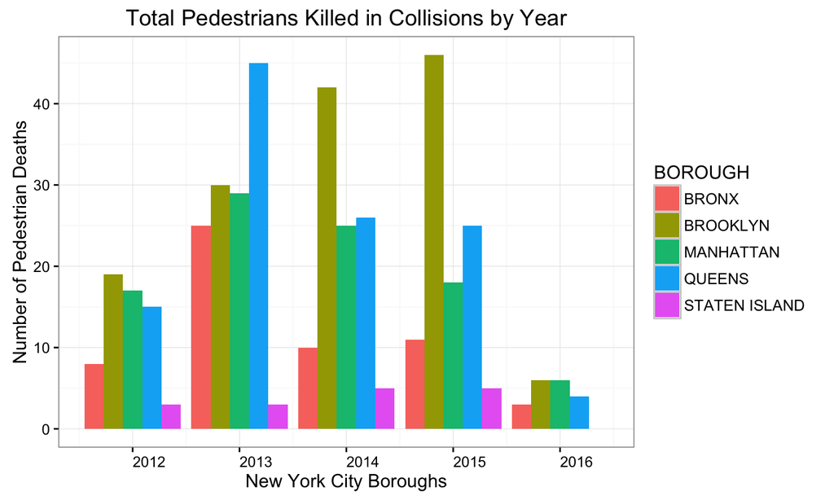

## Total Motorist Deaths by Borough

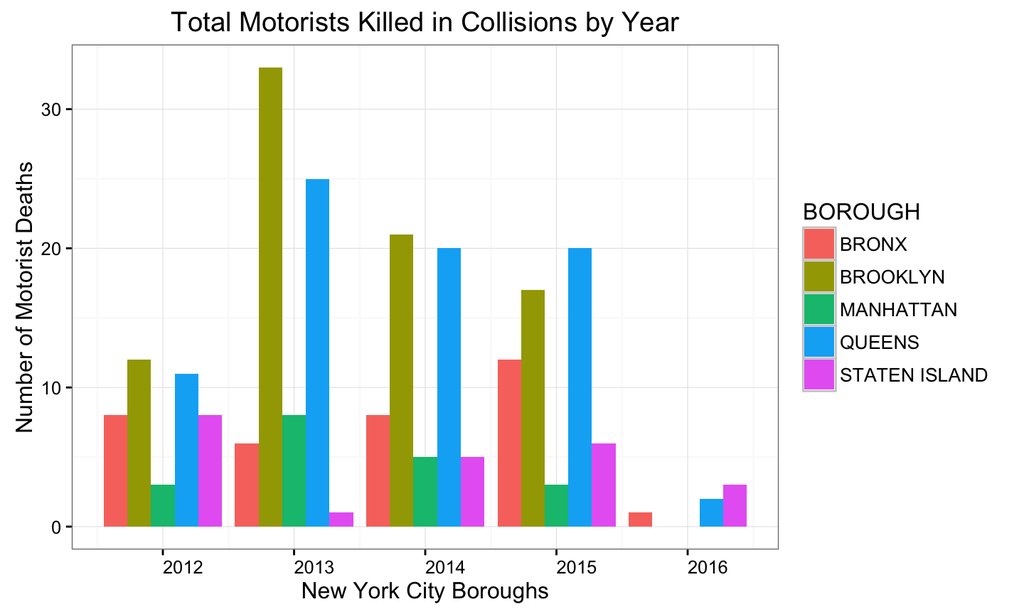

## **Part 3**

### Time of Day Analysis

## Total Deaths by Time of Day

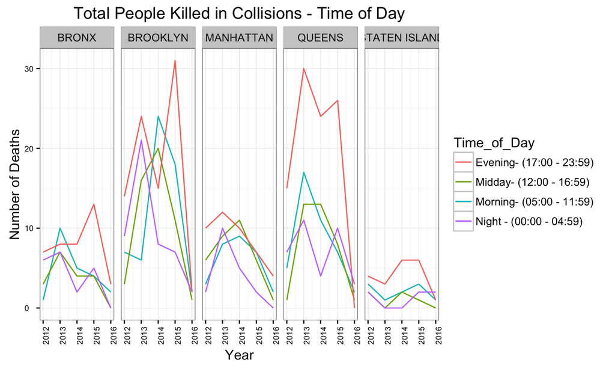

## **Part 4**

### Monthly Analysis

## Total Deaths

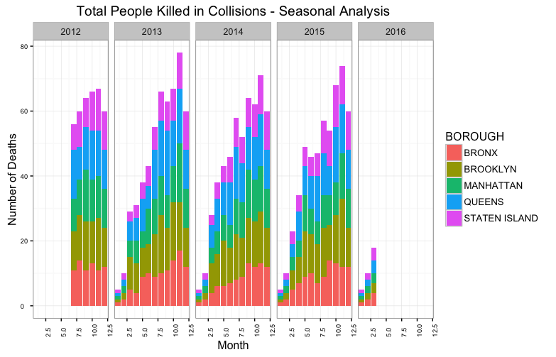

## **Part 5**

### Zip Code Analysis

## Total Deaths by Zip Codes

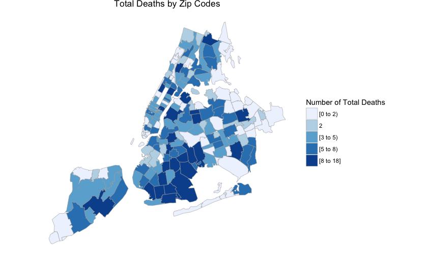

## Total Cyclist Deaths by Zip Codes

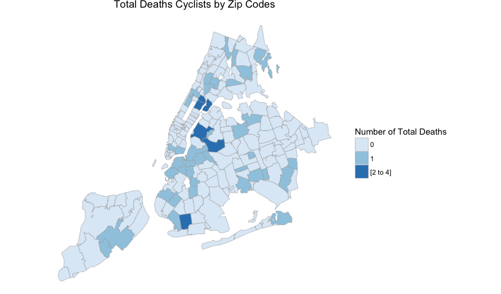

## Total Motorist Deaths by Zip Codes

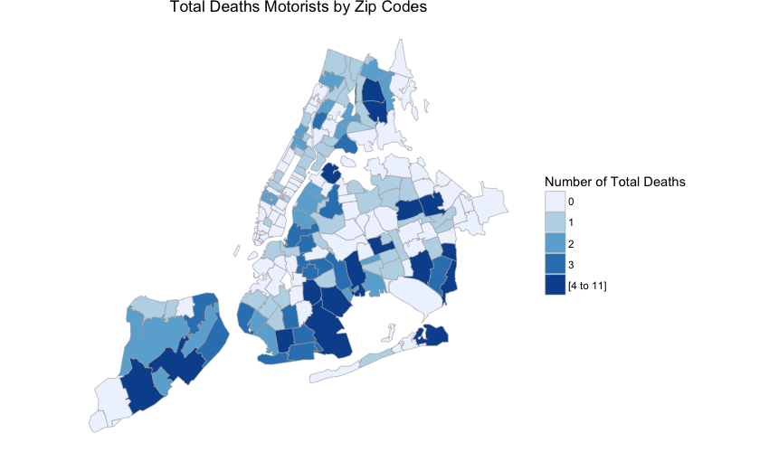

## Total Pedestrian Deaths by Zip Codes

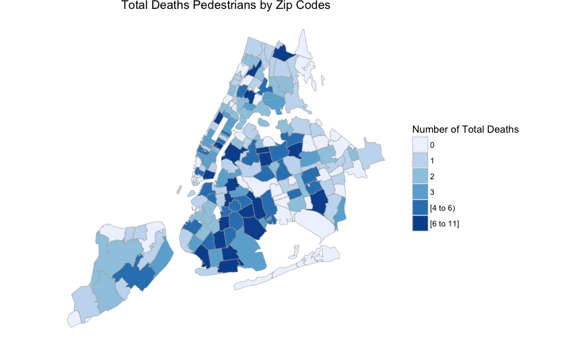

## **Part 6**

### Conclusions and Further Analysis

## Conclusions

1. Brooklyn and Queens seem to have the highest Total Number of Deaths among the New York City (NYC) Boroughs.
2. Collisions in Brooklyn seem to include more Car - Pedestrian type of collisions.
3. Evening and Morning accident numbers seem to be higher than the other times of the day.
4. There is an increasing trend in the number of total deaths, to the end of the year and the maximum death number is reached at the end of the Fall and at the beginning of Winter.

## Further Analysis

1. The effecting factors to collisions
2. Vehicle Types
3. Streetwise Analysis

[figure not shown]